# Models for event counts

Here, I do this by counting the number of MEPs that have hired or fired at least one staffer (i.e. they experienced a change during the period of study).

```r
tab_change <-
  df %>%
  group_by(ID) %>%
  summarize(change = length(unique(y))>1) %>%
  group_by(change) %>%
  summarize(N = n())
tab_change
```

| change | N |
| --- | --- |
| FALSE | 283 |
| TRUE | 891 |

I find that I have

| N |
| --- |
| 891 |

MEPs that have experienced at least one within-individual change in staff size. That’s cool!

I can also chech how many changes individuals experience

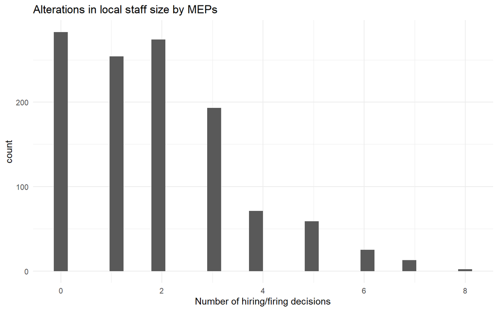

```r
  df %>%
    arrange(Period) %>%
  group_by(ID) %>%
  mutate(change = lag(y) != y) %>%
  group_by(ID) %>%
  summarize(N = sum(change, na.rm = T)) %>%
    dplyr::select(N) %>%
    ggplot +
    geom_histogram(aes(N)) +
  ggtitle("Alterations in local staff size by MEPs") +
  xlab("Number of hiring/firing decisions")
```

Here we see that quite a few MEPs make several changes in their staff during the period of study. It means I can leverage changes over time (if I want to) to observe within-indual effects.

#### Main predictor

My main independent variable is vote share acquired last election. That one too, is metric.

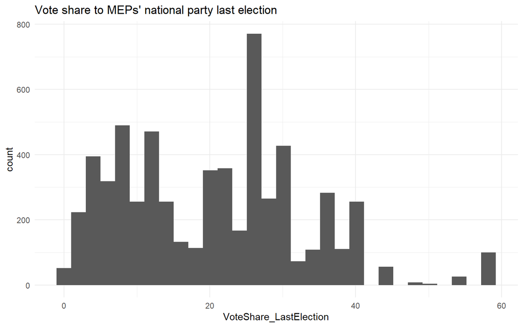

```r
df %>%
  ggplot +
  geom_histogram(aes(VoteShare_LastElection)) +
  ggtitle("Vote share to MEPs' national party last election")
```

A relevant question is whether this one too varies within MEPs; i.e. will I be able to leverage within-individual changes in incentives (vote share) to assess whether they change their behavior (staff size)? Or will I have to rely on cross-sectional variation (between-individuals)?

```r
tab_change <-
  df %>%
  group_by(ID) %>%
  summarize(change = length(unique(VoteShare_LastElection))>1) %>%
  group_by(change) %>%
  summarize(N = n())
tab_change
```

| change | N |
| --- | --- |
| FALSE | 659 |
| TRUE | 515 |

I find that I have

| N |
| --- |
| 515 |

within-individual changes in vote share. This is getting cooler and cooler!

## Bivariate statistics

Let’s explore the bivariate relationship in a pooled data first.

Here, I plot both a smoothed line and a bivariate linear regression.

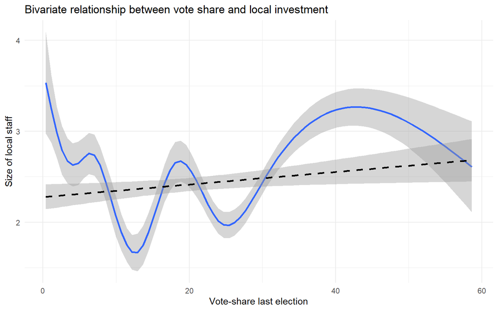

```r
df %>%
  ggplot +
  geom_smooth(aes(x = VoteShare_LastElection,
                  y = y))+
  geom_smooth(aes(x = VoteShare_LastElection,
                  y = y),
              method = "lm",
              lty = 2,
              color = "black") +
  ylab("Size of local staff") +
  xlab("Vote-share last election") +
  ggtitle("Bivariate relationship between vote share and local investment")
```

The loess line indicates first a drop, then an increase. What is going on? The liner model says I should expect more local investment among MEPs that received large support last election; not really what I expected.

Let’s chech how this looks within member states. Member states have different party systems and different ways of aggregating votes to seats, so we may be tapping in to some cross-national variation unrelated to electoral uncertainty as such.

With many groups, it is easier to get a sense of the relationship when I don’t plot the uncertainty. The same goes for linear predictions instead of loess lines. The larger the data, the longer it will take to calculate a loess line as well.

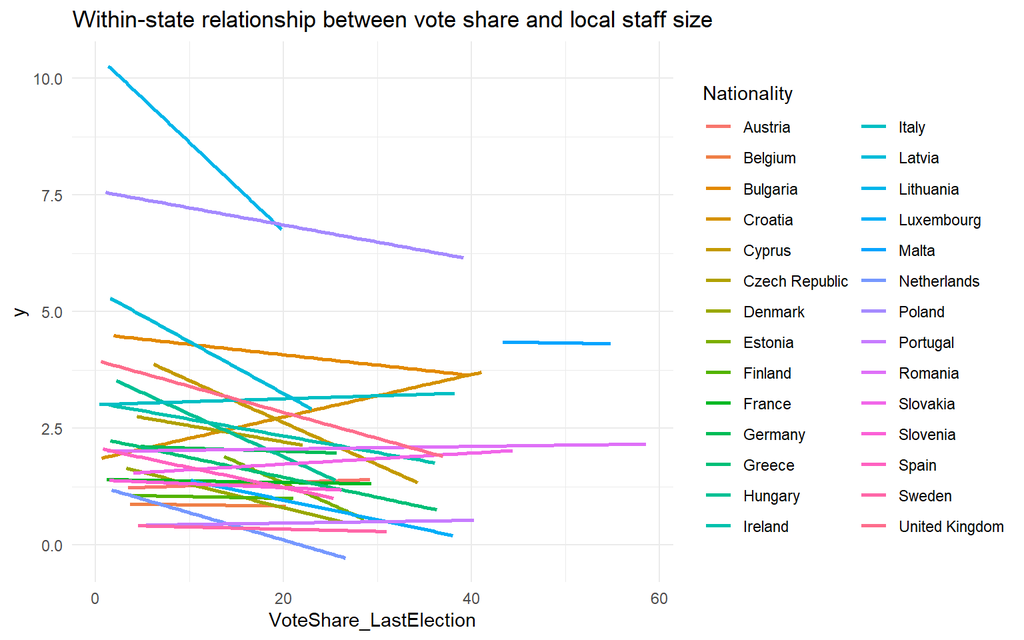

```r
df %>%
  ggplot +
  geom_smooth(aes(x = VoteShare_LastElection,
                  y = y,
                  color = Nationality),
              se = F, method = "lm") +
  ggtitle("Within-state relationship between vote share and local staff size")
```

We get a clear sense that the effect is in fact negative, but was masked by Malta.

## Aggregating data

Another way of exploring hierarchical data is to look at the grouped relationship. Let’s create a new data frame with individual-level covariates. Now, we can explore between-individual variation

I already aggregated data to the individual level when I counted the number of changes in staff. `dplyr` is our friend. Here, I aggregate the dependent variable and include some groupings that dont change over time.

```r
df_id <-
  df %>%
  group_by(Nationality, Female, ID) %>%
  summarize(staff = mean(y),
            vote = mean(VoteShare_LastElection, na.rm = T))
```

Let’s chech the between- individual variation in local investment and vote share.

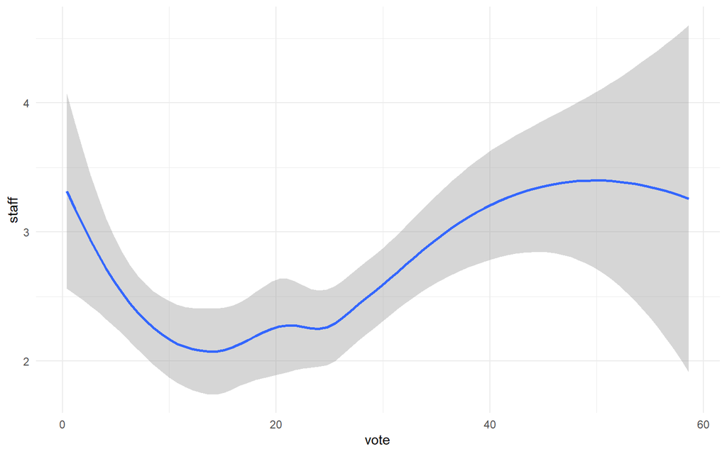

```r
df_id %>%
  ggplot +
  geom_smooth(aes(y = staff,
                  x = vote),
              method = "loess", se = T)
```

We seem to have a curvy relationship again. Is this masked by member states?

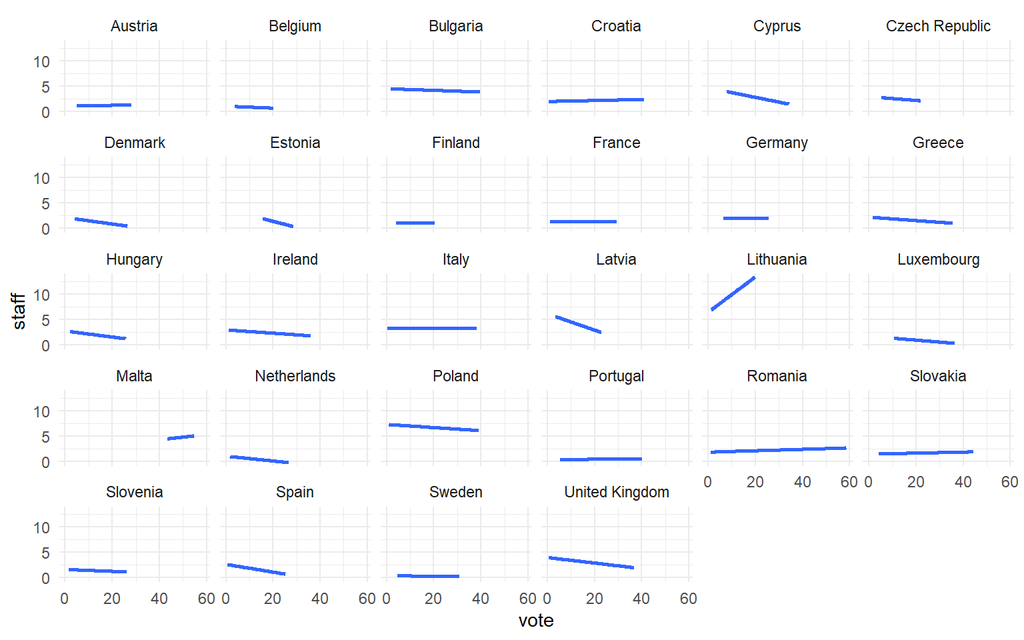

```r
df_id %>%
  ggplot +
  geom_smooth(aes(y = staff,
                  x = vote),
              method = "lm", se = F) +
  facet_wrap(~Nationality)
```

It’s less clear, but most lines seem either flat or decreasing. I’d expect quite a lot of the variation to happen within individuals then; and not between.

If I have cateegorical variables, I can explore the distribution of my numeric outcome (staff) for different categories (men and women respectively).

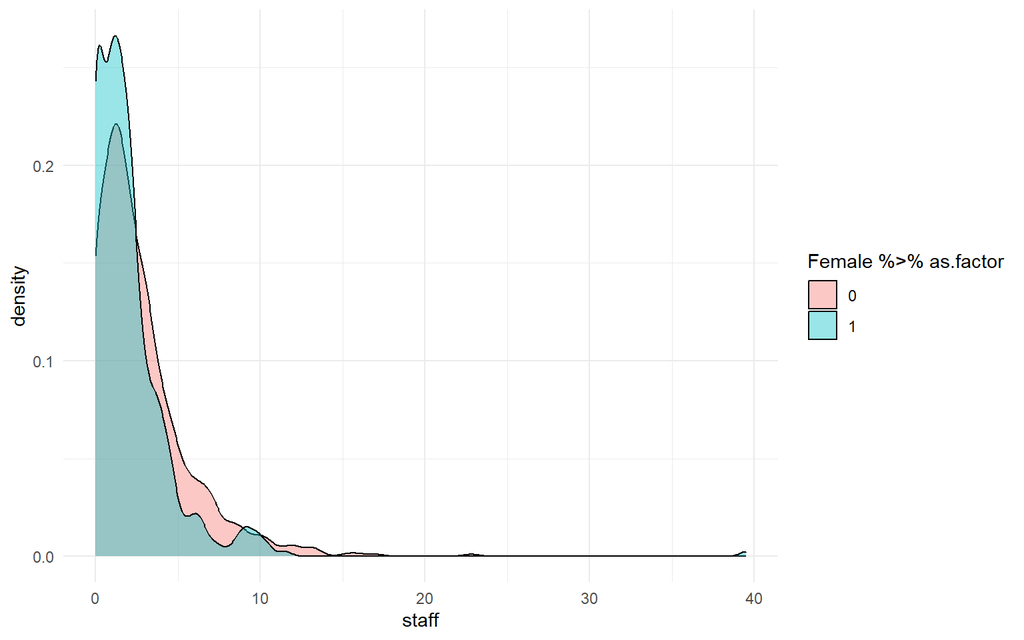

```r
df_id %>%
  filter(!is.na(Female)) %>%
  ggplot() +
  geom_density(aes(staff,
                   fill = Female %>% as.factor),
               alpha = 0.4)
```

There is not a lot to report there; there seems to be slightly more men with larger staff.

#### Over time

In panel data, we may have bumps and drops in the outcome of our dependent variable over time. If I don’t expect a linear trend, I can still calculate group averages.

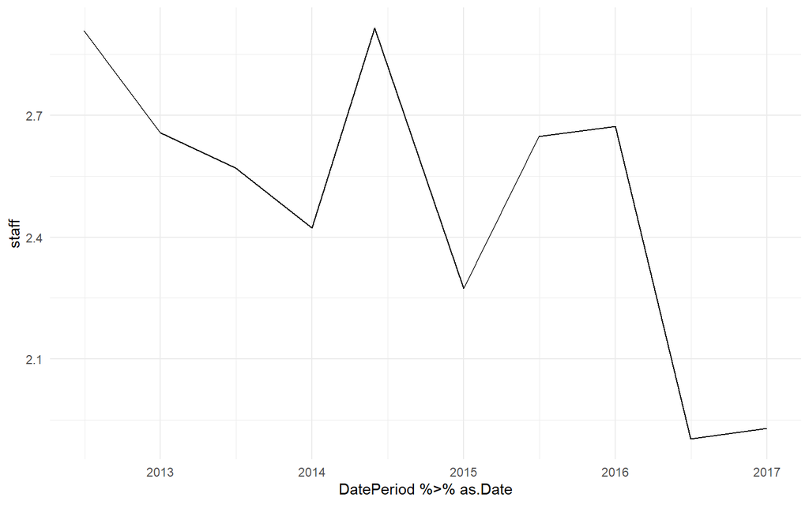

```r
df %>%
  group_by(DatePeriod) %>%
  summarize(staff = mean(y)) %>%
  ggplot +
  geom_line(aes(x = DatePeriod %>% as.Date,
                y = staff))
```

We can note a few thins straight away: We had a jump in the Spring term of 2014 (EU election) and a significant dump right after (new parliament), then a drop after 2016 (reform capping MEPs’ local spending). Plotting variables over time always jolts the imagination.

# Models

Let’s run some models instead.

## Random intercepts

I usually start with a simple pooled analysis with one predictor.

```r
mod.pool <- lm(y ~ VoteShare_LastElection ,
               df)

summary(mod.pool)
```

```
##
## Call:
## lm(formula = y ~ VoteShare_LastElection, data = df)
##
## Residuals:
##    Min     1Q Median     3Q    Max
## -2.681 -1.857 -0.513  0.678 40.661
##
## Coefficients:
##                        Estimate Std. Error t value Pr(>|t|)
## (Intercept)            2.276853   0.070836  32.143   <2e-16 ***
## VoteShare_LastElection 0.006895   0.002967   2.324   0.0202 *
## ---
## Signif. codes:  0 '***' 0.001 '**' 0.01 '*' 0.05 '.' 0.1 ' ' 1
##
## Residual standard error: 2.874 on 6067 degrees of freedom
##   (1074 observations deleted due to missingness)
## Multiple R-squared:  0.0008894,  Adjusted R-squared:  0.0007247
## F-statistic: 5.401 on 1 and 6067 DF,  p-value: 0.02016
```

I find indications that MEPs hold a bigger local staff when they receive a larger vote share. Strange…

I add individual intercepts.

```r
mod.id <- lmer(y ~ VoteShare_LastElection + (1|ID),
               df)

summary(mod.id)
```

```
## Linear mixed model fit by REML ['lmerMod']
## Formula: y ~ VoteShare_LastElection + (1 | ID)
##    Data: df
##
## REML criterion at convergence: 25166.5
##
## Scaled residuals:
##     Min      1Q  Median      3Q     Max
## -7.3248 -0.3010 -0.0621  0.2829 24.7955
##
## Random effects:
##  Groups   Name        Variance Std.Dev.
##  ID       (Intercept) 6.848    2.617
##  Residual             2.291    1.514
## Number of obs: 6069, groups:  ID, 1023
##
## Fixed effects:
##                        Estimate Std. Error t value
## (Intercept)            2.310758   0.127163  18.172
## VoteShare_LastElection 0.008105   0.004641   1.746
##
## Correlation of Fixed Effects:
##             (Intr)
## VtShr_LstEl -0.746
```

I get a stronger effect in the unexpected direction. Yet, I leverage the right kind of variation, don’t I?

#### Fixed effects to leverage within-group variation

I can always go for a fixed-effect model to leverage only within-individual variation (i.e. over time).

```r
mod.id.fix <- lm(y ~ VoteShare_LastElection +
                     as.factor(ID),
               df)

stargazer(mod.id.fix,
          type = "html",
          omit = "as.factor")
```

|  | *Dependent variable:* |
| --- | --- |
|  | y |
| VoteShare_LastElection | 0.003 |
|  | (0.006) |
| Constant | 1.546*** |
|  | (0.489) |
| Observations | 6,069 |
| R<sup>2</sup> | 0.771 |
| Adjusted R<sup>2</sup> | 0.725 |
| Residual Std. Error | 1.509 (df = 5045) |
| F Statistic | 16.604*** (df = 1023; 5045) |
| *Note:* | p<0.1; p<0.05; p<0.01 |

Nope. If the true within-individual effect is masked, it is by something that varies over time. The EP capped the local spending in 2016, so let’s control for that. the same goes for seniority and age.

```r
mod.id.fix.t <- lm(y ~ VoteShare_LastElection +
                     Reform2016 +
                     Incumbent +
                     Age +
                     as.factor(ID),
                   df)

stargazer(mod.id.fix, mod.id.fix.t,
          type = "html",
          omit = "as.factor")
```

|  | *Dependent variable:* |  |
| --- | --- | --- |
|  | y |  |
|  | (1) | (2) |
| VoteShare_LastElection | 0.003 | -0.010 |
|  | (0.006) | (0.006) |
| Reform2016 |  | -0.438*** |
|  |  | (0.069) |
| Incumbent |  | 0.179* |
|  |  | (0.095) |
| Age |  | -0.176*** |
|  |  | (0.027) |
| Constant | 1.546*** | 12.707*** |
|  | (0.489) | (1.709) |
| Observations | 6,069 | 6,069 |
| R<sup>2</sup> | 0.771 | 0.781 |
| Adjusted R<sup>2</sup> | 0.725 | 0.737 |
| Residual Std. Error | 1.509 (df = 5045) | 1.475 (df = 5042) |
| F Statistic | 16.604*** (df = 1023; 5045) | 17.569*** (df = 1026; 5042) |
| *Note:* | p<0.1; p<0.05; p<0.01 |  |

Now, we’re talking! It’s tempting to add the electoral period of 2014 as a control. However, since I assume the lower local investment among MEPs from parties with strong support is due to electoral incentives, I’d be controlling away my own effect.

### Several groups of random effects

Let’s leverage both within- and between-individual variation (for good sports) by reverting to random intercepts. However, I’d like to add yet another group variable: nationality. Nationality controls for other potential confounders. For example, both vote share and staff size are reasonably linked to nationality: One because of the party system, the other because of labor cost.

```r
mod.ran <- lmer(y ~ VoteShare_LastElection
                + (1|ID)
                + (1|Nationality),
               df)

summary(mod.ran)
```

```
## Linear mixed model fit by REML ['lmerMod']
## Formula: y ~ VoteShare_LastElection + (1 | ID) + (1 | Nationality)
##    Data: df
##
## REML criterion at convergence: 24698.1
##
## Scaled residuals:
##     Min      1Q  Median      3Q     Max
## -7.1269 -0.2978 -0.0416  0.2914 24.4319
##
## Random effects:
##  Groups      Name        Variance Std.Dev.
##  ID          (Intercept) 3.654    1.912
##  Nationality (Intercept) 3.695    1.922
##  Residual                2.304    1.518
## Number of obs: 6069, groups:  ID, 1023; Nationality, 28
##
## Fixed effects:
##                         Estimate Std. Error t value
## (Intercept)             2.457426   0.383950    6.40
## VoteShare_LastElection -0.007239   0.004388   -1.65
##
## Correlation of Fixed Effects:
##             (Intr)
## VtShr_LstEl -0.238
```

This time, the effect flips because of my group control.

Let’s add the time-varying controls as well.

```r
mod.ran.t <- lmer(y ~
                  VoteShare_LastElection
                  + Reform2016
                  + Age
                + (1|ID)
                + (1|Nationality),
               df)

summary(mod.ran.t)
```

```
## Linear mixed model fit by REML ['lmerMod']
## Formula: y ~ VoteShare_LastElection + Reform2016 + Age + (1 | ID) + (1 |
##     Nationality)
##    Data: df
##
## REML criterion at convergence: 24497.2
##
## Scaled residuals:
##     Min      1Q  Median      3Q     Max
## -7.4733 -0.2973 -0.0445  0.2993 24.7773
##
## Random effects:
##  Groups      Name        Variance Std.Dev.
##  ID          (Intercept) 3.648    1.910
##  Nationality (Intercept) 3.734    1.932
##  Residual                2.212    1.487
## Number of obs: 6069, groups:  ID, 1023; Nationality, 28
##
## Fixed effects:
##                         Estimate Std. Error t value
## (Intercept)             3.935761   0.494324   7.962
## VoteShare_LastElection -0.011815   0.004349  -2.717
## Reform2016             -0.709434   0.053272 -13.317
## Age                    -0.023262   0.005745  -4.049
##
## Correlation of Fixed Effects:
##             (Intr) VtS_LE Rf2016
## VtShr_LstEl -0.207
## Reform2016   0.071  0.060
## Age         -0.625  0.036 -0.166
```

```r
stargazer(mod.pool,  mod.id, mod.ran, mod.ran.t,
          title = "Random effects (on individual MEPs and their nationality)",
          type = "html")
```

**Random effects (on individual MEPs and their nationality)**

|  | *Dependent variable:* |  |  |  |
| --- | --- | --- | --- | --- |
|  | y |  |  |  |
|  | *OLS* | *linear* |  |  |
|  |  | *mixed-effects* |  |  |
|  | (1) | (2) | (3) | (4) |
| VoteShare_LastElection | 0.007** | 0.008* | -0.007* | -0.012*** |
|  | (0.003) | (0.005) | (0.004) | (0.004) |
| Reform2016 |  |  |  | -0.709*** |
|  |  |  |  | (0.053) |
| Age |  |  |  | -0.023*** |
|  |  |  |  | (0.006) |
| Constant | 2.277*** | 2.311*** | 2.457*** | 3.936*** |
|  | (0.071) | (0.127) | (0.384) | (0.494) |
| Observations | 6,069 | 6,069 | 6,069 | 6,069 |
| R<sup>2</sup> | 0.001 |  |  |  |
| Adjusted R<sup>2</sup> | 0.001 |  |  |  |
| Log Likelihood |  | -12,583.270 | -12,349.030 | -12,248.610 |
| Akaike Inf. Crit. |  | 25,174.550 | 24,708.070 | 24,511.230 |
| Bayesian Inf. Crit. |  | 25,201.390 | 24,741.620 | 24,558.210 |
| Residual Std. Error | 2.874 (df = 6067) |  |  |  |
| F Statistic | 5.401** (df = 1; 6067) |  |  |  |
| *Note:* | p<0.1; p<0.05; p<0.01 |  |  |  |

## Group-level effects

I can add group-level variables to this. The random intercepts are a way to cluster the residuals. The level-two variables are then regressed on these group means.

```r
mod.ran.t.c <- lmer(y ~
                  VoteShare_LastElection
                  + Female
                  + Reform2016
                  + Age
                + (1|ID)
                + (1|Nationality),
               df)

summary(mod.ran.t.c)
```

```
## Linear mixed model fit by REML ['lmerMod']
## Formula: y ~ VoteShare_LastElection + Female + Reform2016 + Age + (1 |
##     ID) + (1 | Nationality)
##    Data: df
##
## REML criterion at convergence: 24487
##
## Scaled residuals:
##     Min      1Q  Median      3Q     Max
## -7.4650 -0.2975 -0.0436  0.3013 24.7727
##
## Random effects:
##  Groups      Name        Variance Std.Dev.
##  ID          (Intercept) 3.638    1.907
##  Nationality (Intercept) 3.660    1.913
##  Residual                2.213    1.487
## Number of obs: 6067, groups:  ID, 1021; Nationality, 28
##
## Fixed effects:
##                         Estimate Std. Error t value
## (Intercept)             4.118588   0.498547   8.261
## VoteShare_LastElection -0.011755   0.004350  -2.702
## Female                 -0.281310   0.134398  -2.093
## Reform2016             -0.705550   0.053314 -13.234
## Age                    -0.024684   0.005779  -4.271
##
## Correlation of Fixed Effects:
##             (Intr) VtS_LE Female Rf2016
## VtShr_LstEl -0.203
## Female      -0.162 -0.022
## Reform2016   0.076  0.060 -0.024
## Age         -0.634  0.035  0.102 -0.168
```

The clustering means that the standard errors are also corrected to account for the correlation within the group (i.e. that observations are not i.i.d.). Here, it also means that the uncertainty of gender accounts for the fact that MEPs in general didn’t change gender during the period of study.

### Cross-level interactions

We can make interactions accross levels. Here, I check whether men and women respond to vote share in the same way.

```r
mod.ran.t.c.i <- lmer(y ~
                  VoteShare_LastElection
                  * Female
                  + Reform2016
                  + Age
                + (1|ID)
                + (1|Nationality),
               df)

summary(mod.ran.t.c.i)
```

```
## Linear mixed model fit by REML ['lmerMod']
## Formula: y ~ VoteShare_LastElection * Female + Reform2016 + Age + (1 |
##     ID) + (1 | Nationality)
##    Data: df
##
## REML criterion at convergence: 24486
##
## Scaled residuals:
##     Min      1Q  Median      3Q     Max
## -7.4273 -0.3010 -0.0464  0.3021 24.7573
##
## Random effects:
##  Groups      Name        Variance Std.Dev.
##  ID          (Intercept) 3.664    1.914
##  Nationality (Intercept) 3.623    1.903
##  Residual                2.207    1.486
## Number of obs: 6067, groups:  ID, 1021; Nationality, 28
##
## Fixed effects:
##                                Estimate Std. Error t value
## (Intercept)                    4.247646   0.499609   8.502
## VoteShare_LastElection        -0.019631   0.005113  -3.840
## Female                        -0.803357   0.222335  -3.613
## Reform2016                    -0.701027   0.053278 -13.158
## Age                           -0.024237   0.005797  -4.181
## VoteShare_LastElection:Female  0.025357   0.008592   2.951
##
## Correlation of Fixed Effects:
##             (Intr) VtS_LE Female Rf2016 Age
## VtShr_LstEl -0.217
## Female      -0.166  0.406
## Reform2016   0.079  0.036 -0.037
## Age         -0.632  0.014  0.037 -0.168
## VtShr_LsE:F  0.085 -0.524 -0.795  0.027  0.031
```

They don’t. Men are more reactive to the party’s support than women.

## Random slopes

We can estimate separate slopes for each country. This is a form of interaction effect. However, we specify it differently. It means we will estimate mini-models within each group. It requires a lot of variation (and will “explain” a lot of variation), so I remove some of the more redundant covariates. Controlling for gender when I already have individual-level intercepts is over the top.

```r
mod.slope <- lmer(y ~
                  + Reform2016
                  + Age
                + (1|ID)
                + (VoteShare_LastElection |Nationality),
               df)
summary(mod.slope)
```

```
## Linear mixed model fit by REML ['lmerMod']
## Formula: y ~ +Reform2016 + Age + (1 | ID) + (VoteShare_LastElection |
##     Nationality)
##    Data: df
##
## REML criterion at convergence: 24426.8
##
## Scaled residuals:
##     Min      1Q  Median      3Q     Max
## -7.1624 -0.3076 -0.0409  0.2968 22.4524
##
## Random effects:
##  Groups      Name                   Variance Std.Dev. Corr
##  ID          (Intercept)            4.02625  2.0066
##  Nationality (Intercept)            8.24286  2.8710
##              VoteShare_LastElection 0.01097  0.1047   -0.88
##  Residual                           2.12779  1.4587
## Number of obs: 6069, groups:  ID, 1023; Nationality, 28
##
## Fixed effects:
##              Estimate Std. Error t value
## (Intercept)  3.245224   0.425967   7.618
## Reform2016  -0.723314   0.052859 -13.684
## Age         -0.020990   0.006012  -3.491
##
## Correlation of Fixed Effects:
##            (Intr) Rf2016
## Reform2016  0.115
## Age        -0.749 -0.180
## optimizer (nloptwrap) convergence code: 0 (OK)
## Model failed to converge with max|grad| = 0.00274656 (tol = 0.002, component 1)
```

We can’t see the random effects, but they are there. Let’s check them out.

# Interpretation

## Random intercepts

The random intercepts are stored, but not immediately reported.

We can always take a look at the coefficients using the `coefficients()` function. It reports the coefficients for all groupings: Their (varying) intercepts, and their slopes regardless of whether they are “fixed” or “vary” by group.

Here, I look at the first coefficients for the 10 first MEPs.

```r
coefficients(mod.slope)$ID[1:10,]
```

|  | VoteShare_LastElection | (Intercept) | Reform2016 | Age |
| --- | --- | --- | --- | --- |
| 840 | 0 | 3.692282 | -0.7233143 | -0.02099024 |
| 988 | 0 | 3.200910 | -0.7233143 | -0.02099024 |
| 997 | 0 | 2.804167 | -0.7233143 | -0.02099024 |
| 1023 | 0 | 5.387775 | -0.7233143 | -0.02099024 |
| 1059 | 0 | 3.213897 | -0.7233143 | -0.02099024 |
| 1073 | 0 | 5.970255 | -0.7233143 | -0.02099024 |
| 1122 | 0 | 2.998645 | -0.7233143 | -0.02099024 |
| 1129 | 0 | 3.855421 | -0.7233143 | -0.02099024 |
| 1164 | 0 | 4.305934 | -0.7233143 | -0.02099024 |
| 1179 | 0 | 2.430176 | -0.7233143 | -0.02099024 |

And here I can see the varying slopes i estimated.

```r
coefficients(mod.slope)$Nationality[1:10,]
```

|  | VoteShare_LastElection | (Intercept) | Reform2016 | Age |
| --- | --- | --- | --- | --- |
| Austria | 0.040236230 | 1.7923093 | -0.7233143 | -0.02099024 |
| Belgium | 0.002756819 | 2.1970670 | -0.7233143 | -0.02099024 |
| Bulgaria | 0.002325005 | 5.1017133 | -0.7233143 | -0.02099024 |
| Croatia | 0.151603118 | -0.4176293 | -0.7233143 | -0.02099024 |
| Cyprus | -0.044914583 | 4.6956253 | -0.7233143 | -0.02099024 |
| Czech Republic | -0.036679810 | 4.2198314 | -0.7233143 | -0.02099024 |
| Denmark | -0.035062158 | 2.9489054 | -0.7233143 | -0.02099024 |
| Estonia | -0.035342534 | 3.3162109 | -0.7233143 | -0.02099024 |
| Finland | 0.020964360 | 2.0636303 | -0.7233143 | -0.02099024 |
| France | -0.004058686 | 2.7563834 | -0.7233143 | -0.02099024 |

I can separate out the “fixed” effects (those that are common for all groups) and the “random” effects (the varying slopes and intercepts) using two functions.

```r
fixef(mod.slope)
```

```
## (Intercept)  Reform2016         Age
##  3.24522415 -0.72331434 -0.02099024
```

And here are the varying ones

```r
ranef(mod.slope)
```

```
## $ID
##          (Intercept)
## 840     0.4470575887
## 988    -0.0443138152
## 997    -0.4410573470
## 1023    2.1425511331
## 1059   -0.0313271030
## 1073    2.7250304459
## 1122   -0.2465788689
## 1129    0.6101969169
## 1164    1.0607100738
## 1179   -0.8150482473
## 1183   -0.0808875249
## 1185   -0.5062726168
## 1186    0.5596368872
```

[output cut: 1043 more lines]

Remember, the group means/varyin intercepts are assumed to be normally distributed, and so are the residuals they are meant to group. In other words, we have 28 distributions at the member-state level. Together, their means *also* constitute a normal distribution.

This is a lot of distributions (and assumptions), so there are some controversy over whether we can reliably estimate them. That’s why the `lme4` package doesn’t report the random intercepts with any p-values. However, R has other packages.

`arm` has two twin functions: `se.fixef()` and `se.ranef()` that are useful.

`merTools` allows us to also simulate the random/varying coefficients.

```r
re <- REsim(mod.ran,
            n.sims = 100)
re %>% head
```

|  | groupFctr | groupID | term | mean | median | sd |
| --- | --- | --- | --- | --- | --- | --- |
| 1 | ID | 840 | (Intercept) | 0.71775005 | 0.75082657 | 0.9165543 |
| 2 | ID | 988 | (Intercept) | -0.67678722 | -0.72933515 | 0.7759811 |
| 3 | ID | 997 | (Intercept) | -0.74796917 | -0.84290702 | 0.8032463 |
| 4 | ID | 1023 | (Intercept) | 1.58275879 | 1.45833596 | 0.6682384 |
| 5 | ID | 1059 | (Intercept) | -0.03081614 | 0.04373759 | 0.7586209 |
| 6 | ID | 1073 | (Intercept) | 2.55958226 | 2.67446258 | 0.7234181 |

the best way is still to display these intercepts graphically. You can use the simulations to construct your own plots: coefplots or density plots are nice possibiliites.

There are a few “ready-mades” out there too.

- `merToools` has a quick and dirty way

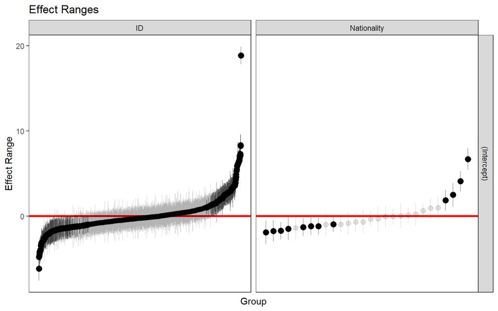

```r
plotREsim(re)
```

It gives us a sense of the variation between the groups. Here, we see that there is still quite some individual-level variation that we haven’t accounted for with other predictors. The groups marked in black have a 95% confidence interval that does not overlap zero. We can also see there are member states that have higher/lower level of local staff than what we might expect.

- `sjPlot` reports effects from all kinds of models. It also gives a nice labelling of our random intercepts.

Here, I only ask for the varying intercept for nationality.

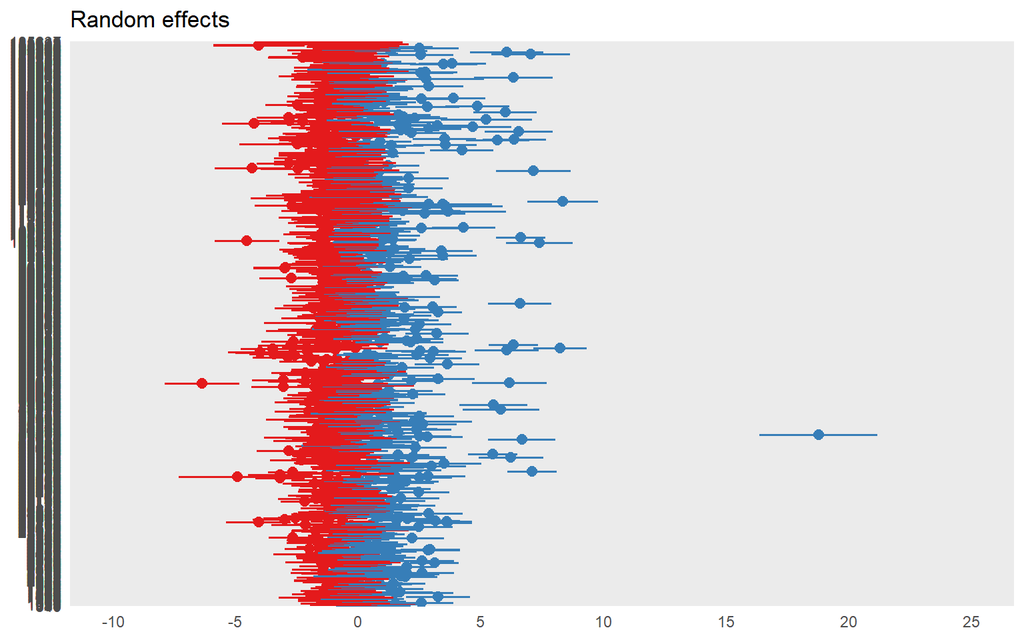

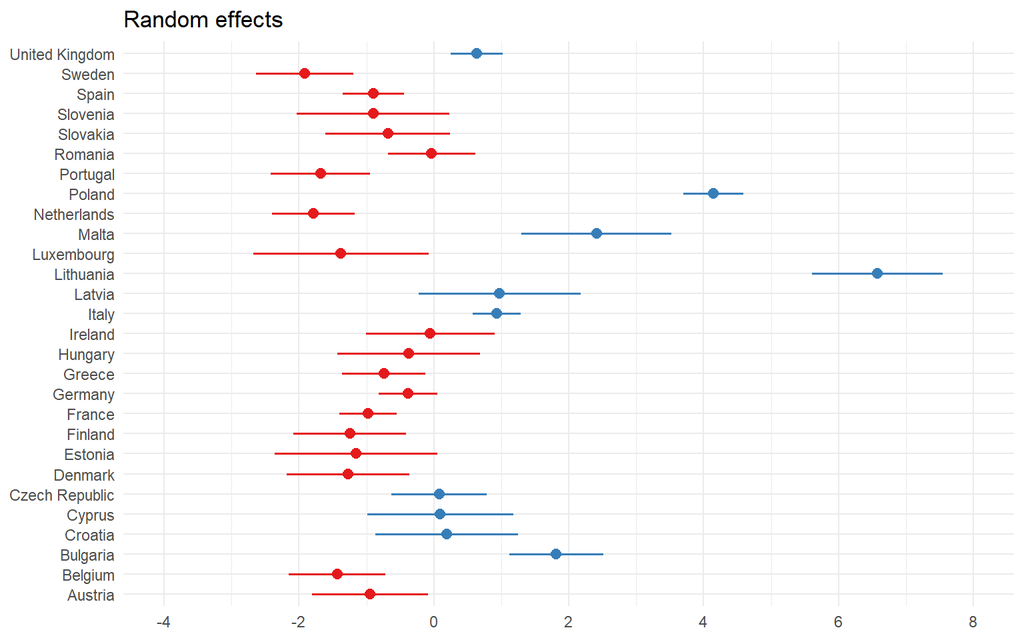

```r
library(sjPlot)
plot_model(mod.ran,
           type = "re",
           terms = "Nationality")
```

Red are states below average; blue are states above average. The color scheme is in relation to the point estimate, not the confidence interval.

## Random slopes

Our random slopes can also be plotted.

We can report the national-level effects of vote shares together with their inercept in `sjPlot`.

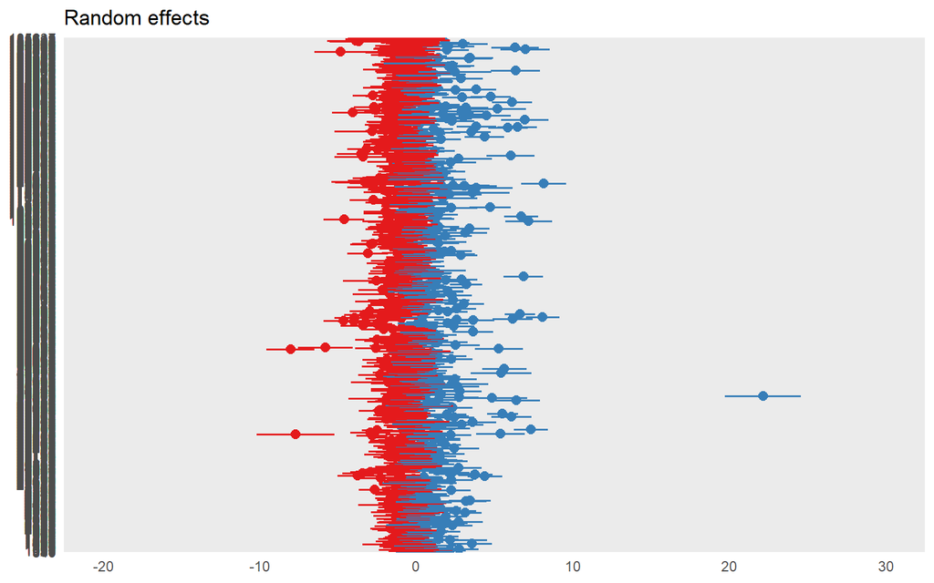

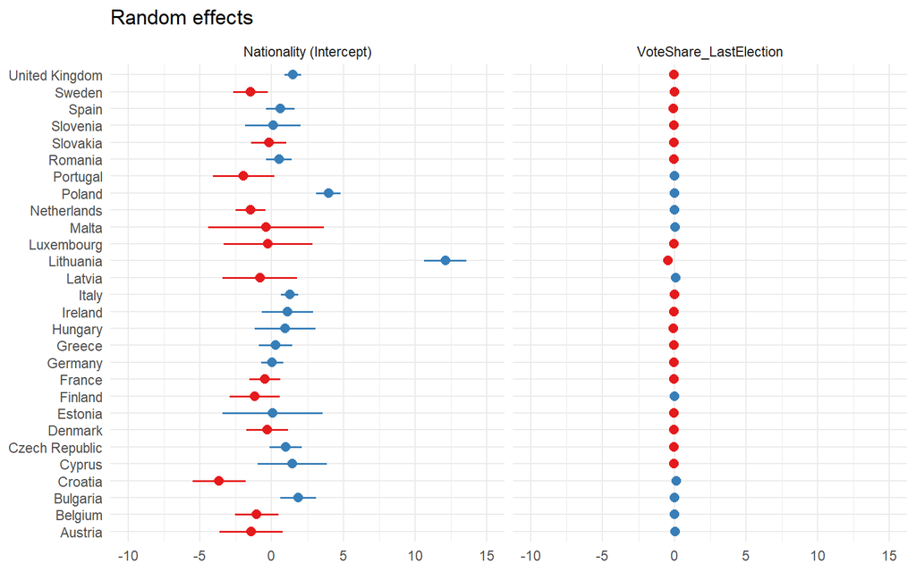

```r
plot_model(mod.slope,
           type = "re",
           terms = "Nationality")
```

Or we can do it our own way:

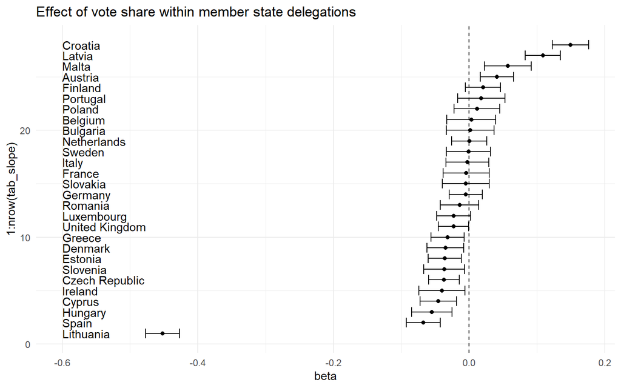

```r
#simulate
re <- REsim(mod.slope) %>%
  as.data.frame() %>%
  #select national variation; those observations without numbers
  filter(grepl("\\D", groupID ))

tab_slope <-
  re %>%
  #Select my variables
  dplyr::select(groupID, term, mean, sd) %>%
  #Pivot to wide format
  tidyr::pivot_wider(values_from = c(mean, sd),
                     names_from = term) %>%
  dplyr::select(1,2,4,3,5) %>%
  rename("alpha" = 2,
         "se(alpha)" = 3,
         "beta" = 4,
         "se(beta)" = 5) %>%
  as.data.frame()

tab_slope %>%
  arrange(beta) %>%
  ggplot +
  geom_point(aes(y = 1:nrow(tab_slope),
                  x = beta)) +
  geom_errorbar(aes(y = 1:nrow(tab_slope),
                    xmin = beta - `se(beta)`*1.96,
                    xmax = beta + `se(beta)`*1.96)
                ) +
  geom_text(aes(y = 1:nrow(tab_slope),
                x = -0.6,
                label = groupID),
            hjust = 0
                ) +
  geom_vline(aes(xintercept = 0),
             lty = 2) +
  ggtitle("Effect of vote share within member state delegations")
```

## Non-varying slopes

The “fixed”/non-varying effecs of the model can be interpreted and displayes as per usual using either your own simulations or the ggeffects package, for example.

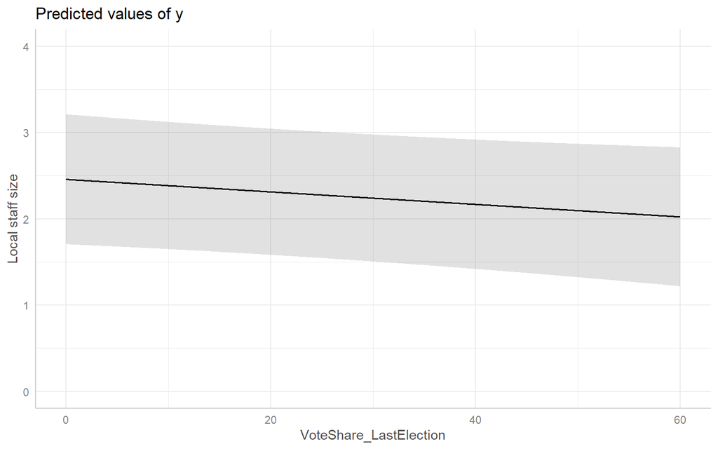

```r
library(ggeffects)

vote_share <- seq(0, 60, 0.1)

dff <- ggpredict(mod.ran,
                 type = "fixed",
                 terms = list(VoteShare_LastElection = vote_share))

dff %>%
  plot +
  ylim(c(0,4)) +
  ylab("Local staff size")
```

The ggeffects package (as well as the sjPlot) includes also variation from the groups, so the precision of the scenarios we make tend to be surrounded with more uncertainty than if we ran a pooled model.

## Regression tables

`stargazer()` is of course a useful package for model displays. However, `sjPlot` also offers a table function that provides more model statistics for hierarchical models

```r
library(sjPlot)

tab_model(mod.pool, mod.id, mod.ran,
          file = "sjplot.html")
```

# Literature

Ward, Michael D., and John S. Ahlquist. 2018. *Maximum Likelihood for Social Science: Strategies for Analysis*. Analytical Methods for Social Research. Cambridge: Cambridge University Press. https://doi.org/10.1017/9781316888544.